# Exploration of PM2.5 Emissions Data

Reginald Carey

March 19, 2015

## Introduction

Fine particulate matter (PM2.5) is an ambient air pollutant for which there is strong evidence that it is harmful to human health. In the United States, the Environmental Protection Agency (EPA) is tasked with setting national ambient air quality standards for fine PM and for tracking the emissions of this pollutant into the atmosphere. Approximatly every 3 years, the EPA releases its database on emissions of PM2.5. This database is known as the National Emissions Inventory (NEI). You can read more information about the NEI at the [EPA National Emissions Inventory web site](http://www.epa.gov/ttn/chief/eiinformation.html).

For each year and for each type of PM source, the NEI records how many tons of PM2.5 were emitted from that source over the course of the entire year. The data that you will use for this assignment are for 1999, 2002, 2005, and 2008.

```r
# Load the data into memory

if (!exists("NEI")) {
    NEI <- readRDS("summarySCC_PM25.rds")
    }
if (!exists("SCC")) {
    SCC <- readRDS("Source_Classification_Code.rds")
    }
```

### Question 1

Have total emissions from PM2.5 decreased in the United States from 1999 to 2008? Using the **base** plotting system, make a plot showing the total PM2.5 emission from all sources for each of the years 1999, 2002, 2005, and 2008.

```r
if (!exists("NEI_SumByYear")) {
    NEI_SumByYear <- aggregate(NEI$Emissions/1000, by = list(Year = NEI$year), FUN = sum)
    names(NEI_SumByYear) <- c("Year", "TotalEmissions")
    }
```

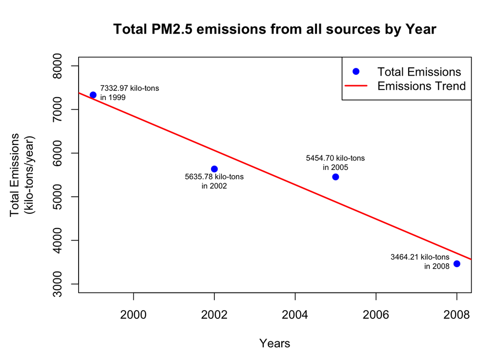

```r
# Set up margins to show our labels
par(mar=c(4.5,5.5,4,2))

# Lets plot the data.
plot(NEI_SumByYear$TotalEmissions ~ NEI_SumByYear$Year,
     main="Total PM2.5 emissions from all sources by Year",
     xlab="Years",
     ylab="Total Emissions\n(kilo-tons/year)",
     lwd=2,
     col="blue",
     pch=19,
     ylim=c(min(floor(NEI_SumByYear$TotalEmissions/1000)*1000),
            max(ceiling(NEI_SumByYear$TotalEmissions/1000)*1000)))

# Lets add a regression line showing the trend
regressionLine <- lm(NEI_SumByYear$TotalEmissions ~ NEI_SumByYear$Year)
abline(regressionLine, col="red",lwd=2)

# Lets put a legend on it so we know what we're looking at
legend("topright",
       legend=c("Total Emissions","Emissions Trend"),
       pty('p','l'),
       pch=c(19,-1),
       lty=c(0,1),
       col=c("blue","red"),
       lwd=2)

# Lets add some labels to each point to explicitly identify the data values
names <- sprintf("%0.2f kilo-tons\nin %d", NEI_SumByYear$TotalEmissions, NEI_SumByYear$Year)
text(NEI_SumByYear$TotalEmissions ~ NEI_SumByYear$Year, labels=names, cex = 0.65, pos=c(4,1,3,2))
```

The above plot shows that there has been a downward trend in total emissions of PM2.5 from 1999 to 2008

### Question 2

Have total emissions from PM2.5 decreased in the **Baltimore City**, Maryland (`fips == "24510"`) from 1999 to 2008? Use the **base** plotting system to make a plot answering this question.

```r
if (!exists("NEI_BaltSumByYear")) {
    NEI_Baltimore <- subset(NEI, fips == "24510")
    NEI_BaltSumByYear <- aggregate(NEI_Baltimore$Emissions/1000, by = list(Year = NEI_Baltimore$year), FUN = sum)
    names(NEI_BaltSumByYear) <- c("Year", "TotalEmissions")
    }
```

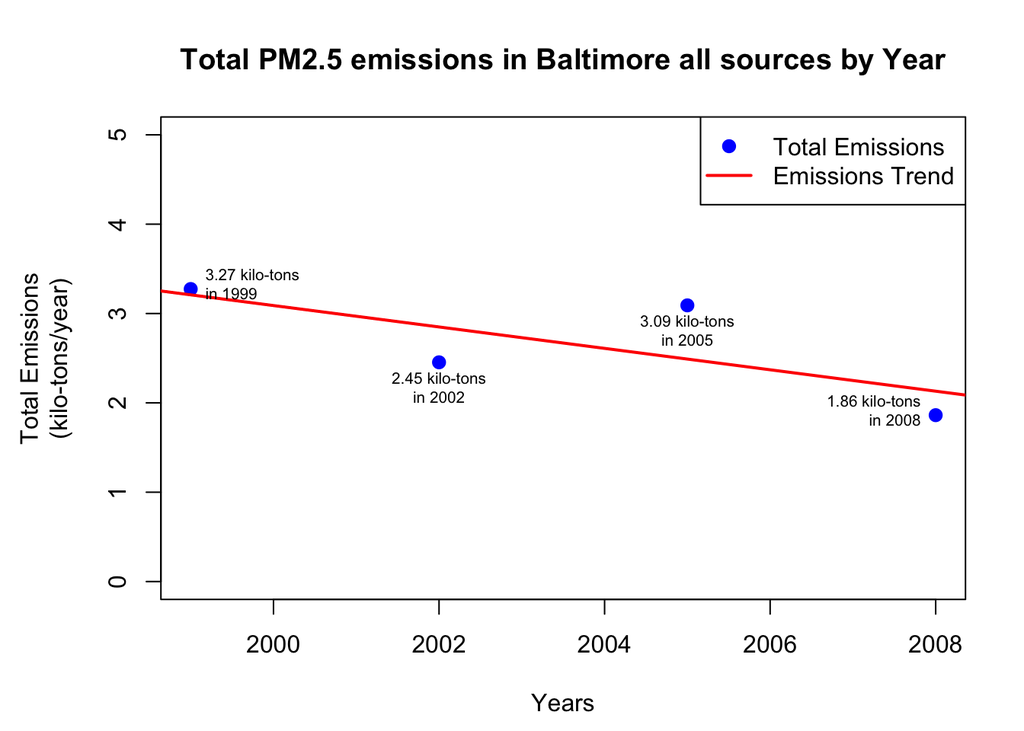

```r
# Set up margins to show our labels
par(mar=c(4.5,5.5,4,2))

# Lets plot the data.
plot(NEI_BaltSumByYear$TotalEmissions ~ NEI_BaltSumByYear$Year,
     main="Total PM2.5 emissions in Baltimore all sources by Year",
     xlab="Years",
     ylab="Total Emissions\n(kilo-tons/year)",
     lwd=2,
     col="blue",
     pch=19,
     ylim=c(min(floor(NEI_BaltSumByYear$TotalEmissions/5)*5),
            max(ceiling(NEI_BaltSumByYear$TotalEmissions/5)*5))
     )

# Lets add a regression line showing the trend
regressionLine <- lm(NEI_BaltSumByYear$TotalEmissions ~ NEI_BaltSumByYear$Year)
abline(regressionLine, col="red",lwd=2)

# Lets put a legend on it so we know what we're looking at
legend("topright",
       legend=c("Total Emissions","Emissions Trend"),
       pty('p','l'),
       pch=c(19,-1),
       lty=c(0,1),
       col=c("blue","red"),
       lwd=2)

# Lets add some labels to each point to explicitly identify the data values
names <- sprintf("%0.2f kilo-tons\nin %d", NEI_BaltSumByYear$TotalEmissions, NEI_BaltSumByYear$Year)
text(NEI_BaltSumByYear$TotalEmissions ~ NEI_BaltSumByYear$Year, labels=names, cex = 0.65, pos=c(4,1,1,2))
```

The above plot shows that there has been a downward trend in total emissions in Baltimore of PM2.5 from 1999 to 2008

### Question 3

Of the four types of sources indicated by the `type` (point, nonpoint, onroad, nonroad) variable, which of these four sources have seen decreases in emissions from 1999–2008 for **Baltimore City**? Which have seen increases in emissions from 1999–2008? Use the **ggplot2** plotting system to make a plot answer this question.

```r
if (!exists("NEI_BaltSumByTypeYear")) {
    NEI_Baltimore <- subset(NEI, fips == "24510")
    NEI_BaltSumByTypeYear <- aggregate(NEI_Baltimore$Emissions,
                                       by = list(NEI_Baltimore$year,NEI_Baltimore$type),
                                       FUN = sum)
    names(NEI_BaltSumByTypeYear) <- c("Year", "Type", "TotalEmissions")
    }
```

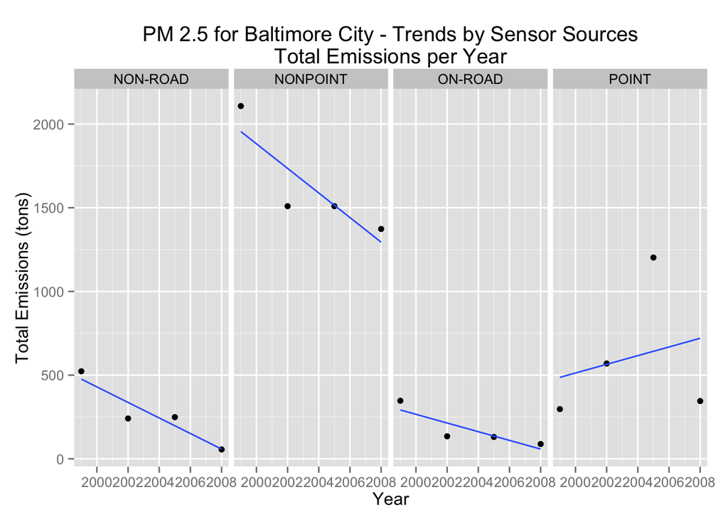

```r
# Use GGPLOT2 Plotting System
library(ggplot2)

# Lets plot the data.
print(
    qplot(Year, TotalEmissions,
          data = NEI_BaltSumByTypeYear,
          facets = . ~ Type,
          geom=c("point", "smooth"),
          method="lm",
          se=FALSE) +
        ggtitle("PM 2.5 for Baltimore City - Trends by Sensor Sources\nTotal Emissions per Year") +
        ylab("Total Emissions (tons)")
    )
```

From the data presented, non-road, non-point, and on-road sensor sources all saw a reduction in total 2.5 particulate matter from 1999 to 2008 in Baltimore City. Point sources increased in Baltimore City over the same period of time.

### Question 4

Across the United States, how have emissions from coal combustion-related sources changed from 1999–2008?

```r
if (!exists("NEI_SumCoalCombustionByYear")) {
    SCC_CoalCombustion <- subset(SCC,
                                 grepl("coal", SCC.Level.Three, ignore.case = TRUE)
                                 & grepl("combustion", SCC.Level.Four, ignore.case = TRUE),
                                 select=SCC)
    NEI_CoalCombustion <- subset(NEI, SCC %in% SCC_CoalCombustion[[1]])
    NEI_SumCoalCombustionByYear <- aggregate(NEI_CoalCombustion$Emissions, by = list(Year = NEI_CoalCombustion$year), FUN = sum)
    names(NEI_SumCoalCombustionByYear) <- c("Year", "TotalEmissions")
    }
```

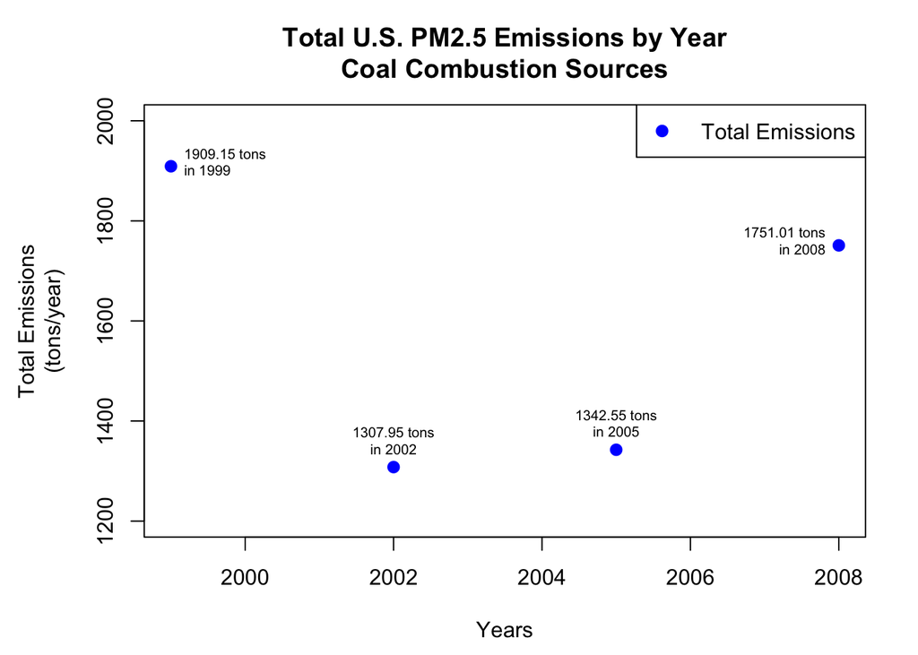

```r
# Set up margins to show our labels
par(mar=c(4.5,5.5,4,2))

# Lets plot the data.
plot(NEI_SumCoalCombustionByYear$TotalEmissions ~ NEI_SumCoalCombustionByYear$Year,
     main="Total U.S. PM2.5 Emissions by Year\nCoal Combustion Sources",
     xlab="Years",
     ylab="Total Emissions\n(tons/year)",
     lwd=2,
     col="blue",
     pch=19,
     ylim=c(1200,2000)
     )

# Lets put a legend on it so we know what we're looking at
legend("topright",
       legend=c("Total Emissions"),
       pty('p'),
       pch=c(19),
       lty=c(0),
       col=c("blue"),
       lwd=2)

# Lets add some labels to each point to explicitly identify the data values
names <- sprintf("%0.2f tons\nin %d", NEI_SumCoalCombustionByYear$TotalEmissions, NEI_SumCoalCombustionByYear$Year)
text(NEI_SumCoalCombustionByYear$TotalEmissions ~ NEI_SumCoalCombustionByYear$Year, labels=names, cex = 0.65, pos=c(4,3,3,2))
```

### Question 5

How have emissions from motor vehicle sources changed from 1999–2008 in **Baltimore City**?

```r
if (!exists("NEI_BaltSumMotorVehicleByYear")) {
    SCC_MotorVehicle <- subset(SCC, grepl("vehicle", Short.Name, ignore.case = TRUE), select=SCC)
    NEI_Baltimore <- subset(NEI, fips == "24510")
    NEI_MotorVehicle <- subset(NEI_Baltimore, SCC %in% SCC_MotorVehicle[[1]])
    NEI_BaltSumMotorVehicleByYear <- aggregate(NEI_MotorVehicle$Emissions, by = list(Year = NEI_MotorVehicle$year), FUN = sum)
    names(NEI_BaltSumMotorVehicleByYear) <- c("Year", "TotalEmissions")
    }
```

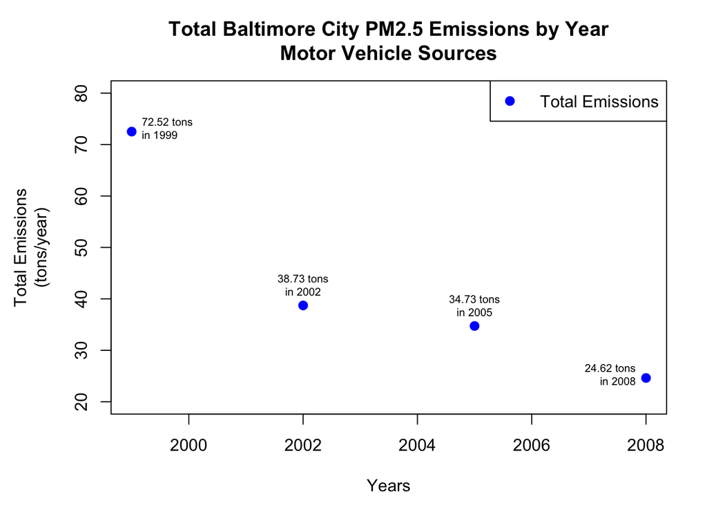

```r
# Set up margins to show our labels
par(mar=c(4.5,5.5,4,2))

# Lets plot the data.
plot(NEI_BaltSumMotorVehicleByYear$TotalEmissions ~ NEI_BaltSumMotorVehicleByYear$Year,
     main = "Total Baltimore City PM2.5 Emissions by Year\nMotor Vehicle Sources",
     xlab = "Years",
     ylab = "Total Emissions\n(tons/year)",
     lwd = 2,
     col = "blue",
     pch = 19,
     ylim = c(20,80)
     )

# Lets put a legend on it so we know what we're looking at
legend("topright",
       legend = c("Total Emissions"),
       pty('p'),
       pch = c(19),
       lty = c(0),
       col = c("blue"),
       lwd = 2)

# Lets add some labels to each point to explicitly identify the data values
names <- sprintf("%0.2f tons\nin %d", NEI_BaltSumMotorVehicleByYear$TotalEmissions, NEI_BaltSumMotorVehicleByYear$Year)
text(NEI_BaltSumMotorVehicleByYear$TotalEmissions ~ NEI_BaltSumMotorVehicleByYear$Year,
     labels = names,
     cex = 0.65,
     pos = c(4,3,3,2))
```

### Question 6

Compare emissions from motor vehicle sources in Baltimore City with emissions from motor vehicle sources in **Los Angeles County**, California (`fips == "06037"`). Which city has seen greater changes over time in motor vehicle emissions?

```r
if (!exists("NEI_BaltSumMotorVehicleByYear")) {
    SCC_MotorVehicle <- subset(SCC, grepl("vehicle", Short.Name, ignore.case = TRUE), select=SCC)
    NEI_Baltimore <- subset(NEI, fips == "24510")
    NEI_MotorVehicle <- subset(NEI_Baltimore, SCC %in% SCC_MotorVehicle[[1]])
    NEI_BaltSumMotorVehicleByYear <- aggregate(NEI_MotorVehicle$Emissions, by = list(Year = NEI_MotorVehicle$year), FUN = sum)
    names(NEI_BaltSumMotorVehicleByYear) <- c("Year", "TotalEmissions")
    }
```

```r
if (!exists("NEI_LosAngelesSumMotorVehicleByYear")) {
    SCC_MotorVehicle <- subset(SCC, grepl("vehicle", Short.Name, ignore.case = TRUE), select=SCC)
    NEI_LosAngeles <- subset(NEI, fips == "06037")
    NEI_MotorVehicle <- subset(NEI_LosAngeles, SCC %in% SCC_MotorVehicle[[1]])
    NEI_LosAngelesSumMotorVehicleByYear <- aggregate(NEI_MotorVehicle$Emissions, by = list(Year = NEI_MotorVehicle$year), FUN = sum)
    names(NEI_LosAngelesSumMotorVehicleByYear) <- c("Year", "TotalEmissions")
    }
```

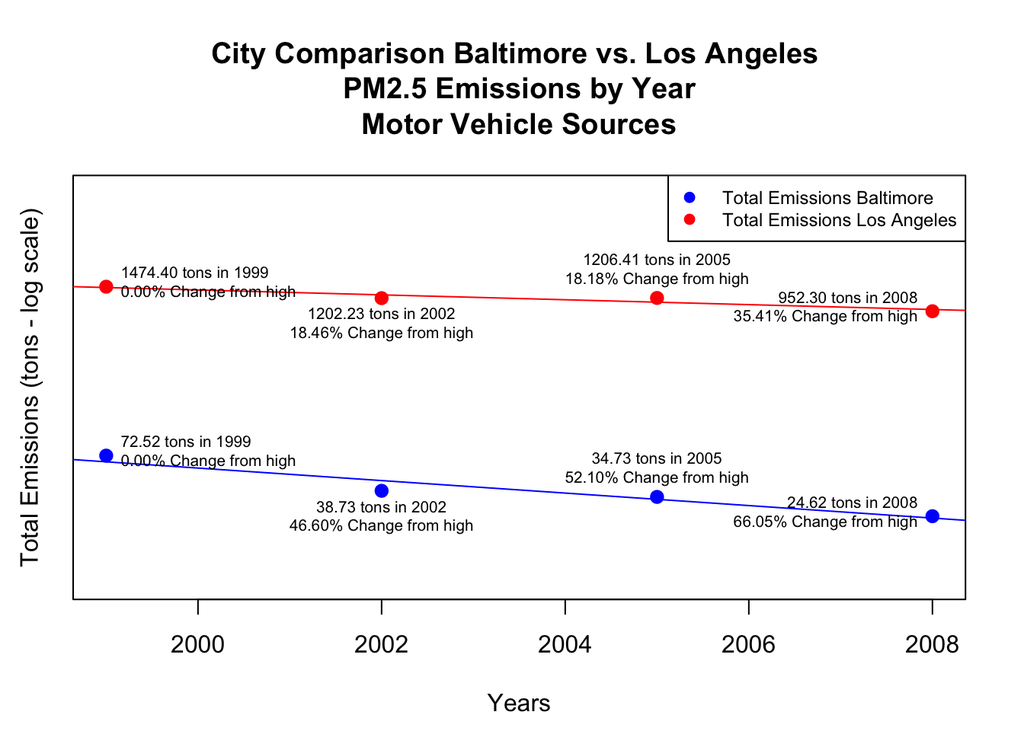

```r
# Set up margins to show our labels
par(mar=c(4.5,2.5,6,2))

# Lets plot the data.
plot(log(NEI_BaltSumMotorVehicleByYear$TotalEmissions) ~ NEI_BaltSumMotorVehicleByYear$Year,
     main = "City Comparison Baltimore vs. Los Angeles \nPM2.5 Emissions by Year\nMotor Vehicle Sources",
     xlab = "Years",
     ylab = "",
     yaxt = "n",
     type = "n",
     ylim = c(2,9)
     )
mtext("Total Emissions (tons - log scale)",side=2,line=1)
points(log(NEI_LosAngelesSumMotorVehicleByYear$TotalEmissions) ~ NEI_LosAngelesSumMotorVehicleByYear$Year,
     lwd = 2,
     pch = 19,
     col = "red",
     type = "p"
     )
abline(lm(log(NEI_LosAngelesSumMotorVehicleByYear$TotalEmissions) ~ NEI_LosAngelesSumMotorVehicleByYear$Year),
     lwd = 1, lty = 1, col = "red",type = "l"
   )
points(log(NEI_BaltSumMotorVehicleByYear$TotalEmissions) ~ NEI_BaltSumMotorVehicleByYear$Year,
     lwd = 2,
     pch = 19,
     col = "blue",
     type = "p"
     )
abline(lm(log(NEI_BaltSumMotorVehicleByYear$TotalEmissions) ~ NEI_BaltSumMotorVehicleByYear$Year),
     lwd = 1, lty = 1, col = "blue", type = "l"
   )
# Lets put a legend on it so we know what we're looking at
legend("topright",
       legend = c("Total Emissions Baltimore","Total Emissions Los Angeles"),
       pty('p'),
       pch = c(19,19),
       lty = c(0),
       col = c("blue","red"),
       cex = 0.75,
       lwd = 2)

# Lets add some labels to each point to explicitly identify the data values

names <- sprintf("%0.2f tons in %d\n%0.2f%% Change from high",
                 NEI_BaltSumMotorVehicleByYear$TotalEmissions,
                 NEI_BaltSumMotorVehicleByYear$Year,
                 100*(1-(NEI_BaltSumMotorVehicleByYear$TotalEmissions/max(NEI_BaltSumMotorVehicleByYear$TotalEmissions))))
text(log(NEI_BaltSumMotorVehicleByYear$TotalEmissions) ~
         NEI_BaltSumMotorVehicleByYear$Year,
     labels = names,
     cex = 0.65,
     pos = c(4,1,3,2))

names <- sprintf("%0.2f tons in %d\n%0.2f%% Change from high",
                 NEI_LosAngelesSumMotorVehicleByYear$TotalEmissions,
                 NEI_LosAngelesSumMotorVehicleByYear$Year,
                 100*(1-(NEI_LosAngelesSumMotorVehicleByYear$TotalEmissions/max(NEI_LosAngelesSumMotorVehicleByYear$TotalEmissions))))
text(log(NEI_LosAngelesSumMotorVehicleByYear$TotalEmissions) ~
         NEI_LosAngelesSumMotorVehicleByYear$Year,
     labels = names,
     cex = 0.65,
     pos = c(4,1,3,2))
```